# Assignment

Rakesh Patel

June 30, 2016

### Introduction

*In this project, we will be to use data from accelerometers on the belt, forearm, arm, and dumbell of 6 participant They were asked to perform barbell lifts correctly and incorrectly in 5 different ways.* *The five ways are exactly according to the specification (Class A), throwing the elbows to the front (Class B), lifting the dumbbell only halfway (Class C), lowering the dumbbell only halfway (Class D) and throwing the hips to the front (Class E). Only Class A corresponds to correct performance.*

The goal of this project is to predict the manner in which they did the exercise, i.e., Class A to E. More information is available from the website [here] (http://groupware.les.inf.puc-rio.br/har)

### Loading different packages

```r
library(caret)
library(randomForest)
library(rattle)
```

## reading the test and train datasets

```r
setwd("E:/Documents/Network/R/8")
train_data<-read.csv("pml-training.csv",na.strings = c("","NA","NULL"))
test_data<-read.csv("pml-testing.csv",na.strings = c("","NA","NULL"))
dim(train_data)
```

```
## [1] 19622   160
```

```r
dim(test_data)
```

```
## [1]  20 160
```

## Cleaning the data

1. Removing columns which has all NA values

```r
train_data_clean1<-train_data[,colSums(is.na(train_data))==0]
dim(train_data_clean1)
```

```
## [1] 19622    60
```

2. Removing columns which are totally meaningless for our model.

```r
drops<-c("X","user_name","raw_timestamp_part_1","raw_timestamp_part_2","cvtd_timestamp","new_window","num_window")
#drops<-names(train_data_clean1)[1:7]
drops
```

```
## [1] "X"                    "user_name"            "raw_timestamp_part_1"
## [4] "raw_timestamp_part_2" "cvtd_timestamp"       "new_window"
## [7] "num_window"
```

```r
train_data_clean2<-train_data_clean1[,-which(names(train_data_clean1) %in% drops)]
dim(train_data_clean2)
```

```
## [1] 19622    53
```

3. Removing zero Covariates

```r
nsv<-nearZeroVar(train_data_clean2[sapply(train_data_clean2,is.numeric)],saveMetrics = TRUE)
#sapply to go only with columns which columns have numeric class
train_data_clean2_nsv<-train_data_clean2[,nsv[,"nzv"]==0]
dim(train_data_clean2_nsv)
```

```
## [1] 19622    53
```

4. Removing highly correlated variables with 80% or more correlation

```r
cor_matrix<-cor(na.omit(train_data_clean2_nsv[sapply(train_data_clean2_nsv, is.numeric)]))
dim(cor_matrix)
```

```
## [1] 52 52
```

```r
dropping_corr<-findCorrelation(cor_matrix,cutoff = 0.80,verbose = TRUE)
```

```
## Compare row 10  and column  1 with corr  0.992
##   Means:  0.27 vs 0.168 so flagging column 10
## Compare row 1  and column  9 with corr  0.925
##   Means:  0.25 vs 0.164 so flagging column 1
## Compare row 9  and column  4 with corr  0.928
##   Means:  0.233 vs 0.161 so flagging column 9
## Compare row 36  and column  29 with corr  0.849
##   Means:  0.251 vs 0.158 so flagging column 36
## Compare row 8  and column  2 with corr  0.966
##   Means:  0.239 vs 0.154 so flagging column 8
## Compare row 2  and column  11 with corr  0.884
##   Means:  0.221 vs 0.15 so flagging column 2
## Compare row 21  and column  24 with corr  0.814
##   Means:  0.194 vs 0.149 so flagging column 21
## Compare row 34  and column  28 with corr  0.808
##   Means:  0.185 vs 0.146 so flagging column 34
## Compare row 25  and column  26 with corr  0.814
##   Means:  0.154 vs 0.145 so flagging column 25
## Compare row 19  and column  18 with corr  0.918
##   Means:  0.096 vs 0.146 so flagging column 18
## Compare row 46  and column  45 with corr  0.846
##   Means:  0.11 vs 0.149 so flagging column 45
## Compare row 46  and column  31 with corr  0.914
##   Means:  0.091 vs 0.152 so flagging column 31
## Compare row 46  and column  33 with corr  0.933
##   Means:  0.07 vs 0.156 so flagging column 33
## All correlations <= 0.8
```

```r
train_data_clean2_nsv_non_cor<-train_data_clean2_nsv[,-dropping_corr]
dim(train_data_clean2_nsv_non_cor)
```

```
## [1] 19622    40
```

## splitting dataset for training and testing

```r
inTrain<-createDataPartition(y=train_data_clean2_nsv_non_cor$classe,p=0.7)[[1]]
training<-train_data_clean2_nsv_non_cor[inTrain,]
dim(training)
```

```
## [1] 13737    40
```

```r
testing<-train_data_clean2_nsv_non_cor[-inTrain,]
dim(testing)
```

```
## [1] 5885   40
```

## Using rpart method ,considering k=5 when doing k-fold cross validation

```r
control <- trainControl(method = "cv", number = 5)
mod_rpart<-train(classe ~ . , data=training,method="rpart",trControl = control)
print(mod_rpart)
```

```
## CART
##
## 13737 samples
##    39 predictor
##     5 classes: 'A', 'B', 'C', 'D', 'E'
##
## No pre-processing
## Resampling: Cross-Validated (5 fold)
## Summary of sample sizes: 10991, 10989, 10989, 10988, 10991
## Resampling results across tuning parameters:
##
##   cp          Accuracy   Kappa
##   0.02044553  0.5677378  0.4570427
##   0.03519479  0.5252890  0.3993135
##   0.04190825  0.4114982  0.2145120
##
## Accuracy was used to select the optimal model using  the largest value.
## The final value used for the model was cp = 0.02044553.
```

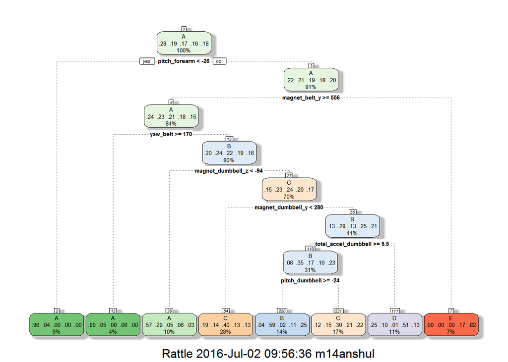

```r
fancyRpartPlot(mod_rpart$finalModel)
```

```r
pred_rpart<-predict(mod_rpart,testing)
confusionMatrix(pred_rpart,testing$classe)
```

```
## Confusion Matrix and Statistics
##
##           Reference
## Prediction    A    B    C    D    E
##          A 1057  181   26   34   19
##          B   20  493   23   87  209
##          C  453  409  971  422  423
##          D  142   56    6  326   66
##          E    2    0    0   95  365
##
## Overall Statistics
##
##                Accuracy : 0.5458
##                  95% CI : (0.533, 0.5586)
##     No Information Rate : 0.2845
##     P-Value [Acc > NIR] : < 2.2e-16
##
##                   Kappa : 0.4313
##  Mcnemar's Test P-Value : < 2.2e-16
##
## Statistics by Class:
##
##                      Class: A Class: B Class: C Class: D Class: E
## Sensitivity            0.6314  0.43284   0.9464   0.3382  0.33734
## Specificity            0.9383  0.92857   0.6487   0.9451  0.97980
## Pos Pred Value         0.8026  0.59255   0.3626   0.5470  0.79004
## Neg Pred Value         0.8649  0.87216   0.9829   0.8794  0.86779
## Prevalence             0.2845  0.19354   0.1743   0.1638  0.18386
## Detection Rate         0.1796  0.08377   0.1650   0.0554  0.06202
## Detection Prevalence   0.2238  0.14138   0.4551   0.1013  0.07850
## Balanced Accuracy      0.7848  0.68070   0.7975   0.6417  0.65857
```

## see the overall accuracy for rpart model

```r
confusionMatrix(pred_rpart,testing$classe)$overall[1]
```

```
##  Accuracy
## 0.5457944
```

## Using randomforest Method

```r
mod_rf<-train(classe ~ .,data = training,method="rf",ntree=100)
pred_rf<-predict(mod_rf,testing)
confusionMatrix(pred_rf,testing$classe)
```

```
## Confusion Matrix and Statistics
##
##           Reference
## Prediction    A    B    C    D    E
##          A 1670    7    0    0    0
##          B    2 1129    4    0    0
##          C    0    3 1017   10    0
##          D    0    0    5  951    1
##          E    2    0    0    3 1081
##
## Overall Statistics
##
##                Accuracy : 0.9937
##                  95% CI : (0.9913, 0.9956)
##     No Information Rate : 0.2845
##     P-Value [Acc > NIR] : < 2.2e-16
##
##                   Kappa : 0.992
##  Mcnemar's Test P-Value : NA
##
## Statistics by Class:
##
##                      Class: A Class: B Class: C Class: D Class: E
## Sensitivity            0.9976   0.9912   0.9912   0.9865   0.9991
## Specificity            0.9983   0.9987   0.9973   0.9988   0.9990
## Pos Pred Value         0.9958   0.9947   0.9874   0.9937   0.9954
## Neg Pred Value         0.9990   0.9979   0.9981   0.9974   0.9998
## Prevalence             0.2845   0.1935   0.1743   0.1638   0.1839
## Detection Rate         0.2838   0.1918   0.1728   0.1616   0.1837
## Detection Prevalence   0.2850   0.1929   0.1750   0.1626   0.1845
## Balanced Accuracy      0.9980   0.9950   0.9943   0.9926   0.9990
```

## see the overall accuracy for randomForest model

```r
confusionMatrix(pred_rf,testing$classe)$overall[1]
```

```
##  Accuracy
## 0.9937128
```

## accuracy is pretty good so we go with Randomforest Method

## Now getting results for our given testing_data using randomforest model

```r
dim(test_data)
```

```
## [1]  20 160
```

```r
Results<-predict(mod_rf,test_data)
Results
```

```
##  [1] B A B A A E D B A A B C B A E E A B B B
## Levels: A B C D E
```

So,for given 20 observation of test_data the above is our predicted result.